# White Wine Analysis by David DeSimone

### Talk about some of the relationships you observed in this part of the investigation. Were there features that strengthened each other in terms of looking at your feature(s) of interest?

This section mostly reinforeced the assumptions and observations from earlier analysis. Alcohol and desnity are driving factors of wine quality. Thee other variables can add to this correlation to quality, but they revolve around the more important variables.

### Were there any interesting or surprising interactions between features?

Density and residual sugar both have negative correlations with quality. But wines with higher quality were more relatively more likely to fall higher in the sugar/density ratio than average wines. Bad wines seems concentrated on the lower end of this ratio.

# Final Plots and Summary

### Plot One

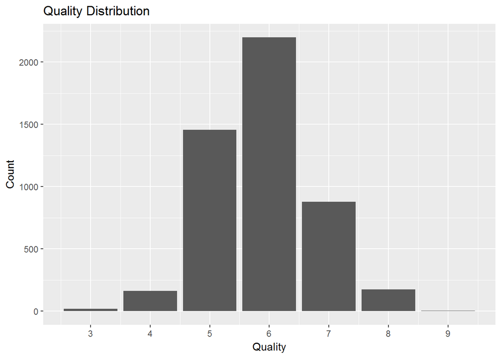

### Description One

Quality is the most important variable and is one of the few variables that, alone, we know we need to care about. Quality is the assumed to be determined by the combination of the other variables.

### Plot Two

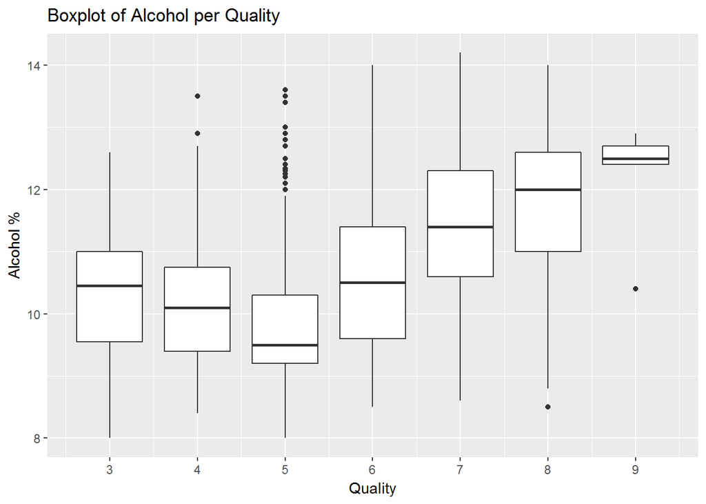

### Description Two

Alcohol has the highest correlation to quality of all the variables. This boxplot helps us more easily see this correlation. Interestingly, wines with ratings of 3 and 4 don’t fall into the trend, but they still have lower alcohol than anything with a 6 or above rating.

### Plot Three

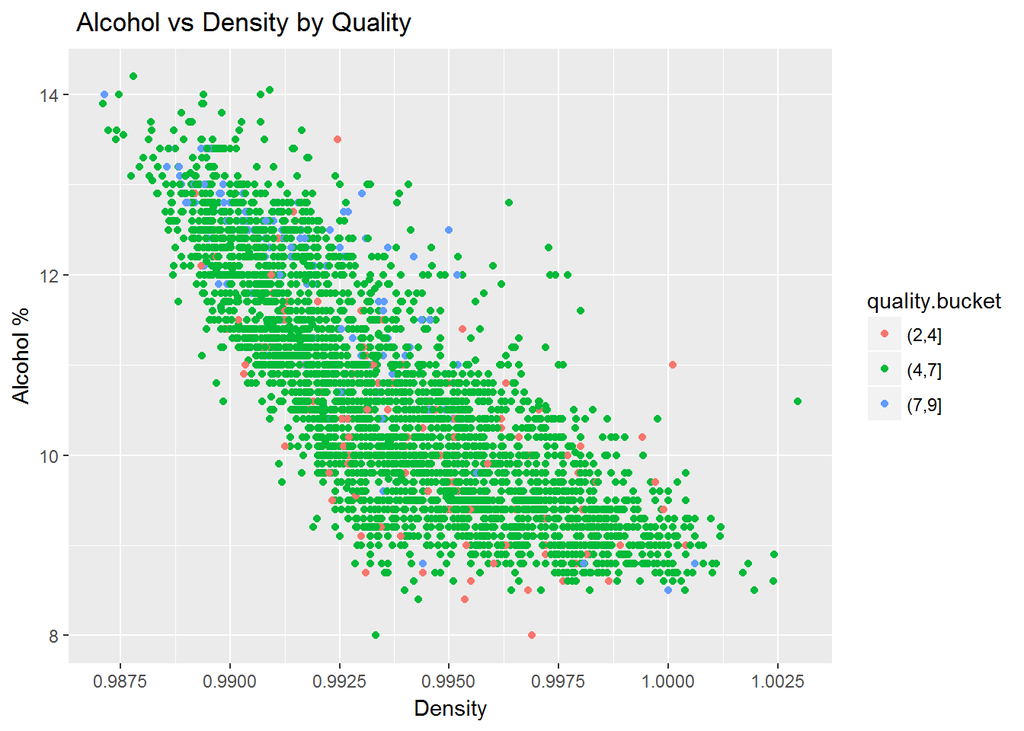

### Description Three

Density had the second highest correlation(inverse) to quality. It is interesting to see how strong the effect is when density is paired with alcohol. We can see some synergy between the two, but it doesn’t knock us off of our feet. Some of the highest rated wines are where we would least expect.

# Reflection

This dataset was composed of 12 measurable variables and one subjective variable(quality – which is most important). Most variables had a normal distribution pattern, the standouts being residual sugar and alcohol. This was interesting because we know that both variables are discernible by human judges, and we know that people might have different preferences in these two areas. Through the analysis, we saw that alcohol and density were really the only two variables with a notable effect on quality. A few of the input variables had high correlations with each other, but I couldn’t attribute them to the final quality score.

While this was a big, clean data set with plenty of variables, the value of using these variables to measure quality is highly questionable. First of all, we don’t know which of these variables are detectable to the human senses. We could argue that the variables that have negligible correlation to quality are useless because quality is completely subjective and is the only variable that we truely care about! Also, there could be other factors that have significant effects on quality but were not measured in this study(something like flavor notes). We don’t know if the testers knew the price of these wines or were influenced by the bottle label. If there are not any other valuable measures that significantly predict quality of the wine, perhaps we should remember that wine quality is highly dependent on personal opinion. One person’s top wine is another’s bottom.